# Saumya Kothari - Applied Statistics Project [Insurance]

## Data Description:

The data at hand contains medical costs of people characterized by certain attributes.

## Domain:

Healthcare

## Context:

Leveraging customer information is paramount for most businesses. In the case of an insurance company, attributes of customers like the ones mentioned below can be crucial in making business decisions. Hence, knowing to explore and generate value out of such data can be an invaluable skill to have.

## Attribute Information:

- age: age of primary beneficiary
- sex: insurance contractor gender, female, male
- bmi: Body mass index, providing an understanding of body, weights that are relatively high or low relative to height, objective index of body weight (kg / m ^2) using the ratio of height to weight, ideally 18.5 to 24.9
- children: Number of children covered by health insurance / Number of dependents
- smoker: Smoking
- region: the beneficiary's residential area in the US, northeast, southeast,southwest, northwest.
- charges: Individual medical costs billed by health insurance.

## Learning Outcomes:

- Exploratory Data Analysis
- Practicing statistics using Python
- Hypothesis testing

```python
# Q1) Import the necessary libraries
```

```python
import pandas as pd
import numpy as np
import matplotlib.pyplot as plt
import seaborn as sns
import os
import scipy.stats as stats
from scipy.stats import skew

sns.set(color_codes = True)
```

```python
# Q2) Read the data as a data frame
```

```python
insurance = pd.read_csv("insurance.csv")
```

```python
df = pd.DataFrame(insurance)
df
```

|  | age | sex | bmi | children | smoker | region | charges |
| --- | --- | --- | --- | --- | --- | --- | --- |
| 0 | 19 | female | 27.900 | 0 | yes | southwest | 16884.92400 |
| 1 | 18 | male | 33.770 | 1 | no | southeast | 1725.55230 |
| 2 | 28 | male | 33.000 | 3 | no | southeast | 4449.46200 |
| 3 | 33 | male | 22.705 | 0 | no | northwest | 21984.47061 |
| 4 | 32 | male | 28.880 | 0 | no | northwest | 3866.85520 |
| ... | ... | ... | ... | ... | ... | ... | ... |
| 1333 | 50 | male | 30.970 | 3 | no | northwest | 10600.54830 |
| 1334 | 18 | female | 31.920 | 0 | no | northeast | 2205.98080 |
| 1335 | 18 | female | 36.850 | 0 | no | southeast | 1629.83350 |
| 1336 | 21 | female | 25.800 | 0 | no | southwest | 2007.94500 |
| 1337 | 61 | female | 29.070 | 0 | yes | northwest | 29141.36030 |

1338 rows × 7 columns

```python
# Q3) Perform basic EDA which should include the following and print out your insights at every step.
```

```python
# Q3) (a) Shape of the data
```

```python
shape = df.shape
print('DataFrame Shape :', shape)
print('Number of rows :', shape[0])
print('Number of columns :', shape[1])

print('Size of DataFrame :', df.size)
```

```
DataFrame Shape : (1338, 7)
Number of rows : 1338
Number of columns : 7
Size of DataFrame : 9366
```

```python
# Q3) (b) Data type of each attribute
```

```python
datatypes_result = df.dtypes

print(datatypes_result)
# In the below output, the syntax followed is the data type followed by the number of bits it can store
```

```
age           int64
sex          object
bmi         float64
children      int64
smoker       object
region       object
charges     float64
dtype: object
```

```python
df.info() #Gives further information about data types and memory
```

```
<class 'pandas.core.frame.DataFrame'>
RangeIndex: 1338 entries, 0 to 1337
Data columns (total 7 columns):
 #   Column    Non-Null Count  Dtype
---  ------    --------------  -----
 0   age       1338 non-null   int64
 1   sex       1338 non-null   object
 2   bmi       1338 non-null   float64
 3   children  1338 non-null   int64
 4   smoker    1338 non-null   object
 5   region    1338 non-null   object
 6   charges   1338 non-null   float64
dtypes: float64(2), int64(2), object(3)
memory usage: 57.6+ KB
```

```python
# Q3) (c) Checking the presence of missing values
```

```python
df.isna()
# This function checks if any null values are null or N/A (not applicable) and returns boolean value
# From the given data we see all false values and hence we further check
```

|  | age | sex | bmi | children | smoker | region | charges |
| --- | --- | --- | --- | --- | --- | --- | --- |
| 0 | False | False | False | False | False | False | False |
| 1 | False | False | False | False | False | False | False |
| 2 | False | False | False | False | False | False | False |
| 3 | False | False | False | False | False | False | False |
| 4 | False | False | False | False | False | False | False |
| ... | ... | ... | ... | ... | ... | ... | ... |
| 1333 | False | False | False | False | False | False | False |
| 1334 | False | False | False | False | False | False | False |
| 1335 | False | False | False | False | False | False | False |
| 1336 | False | False | False | False | False | False | False |
| 1337 | False | False | False | False | False | False | False |

1338 rows × 7 columns

```python
df.isna().any()
# We can see that in all the corresponding columns there are no null values
```

```
age         False
sex         False
bmi         False
children    False
smoker      False
region      False
charges     False
dtype: bool
```

```python
df.isna().sum()
```

```
age         0
sex         0
bmi         0
children    0
smoker      0
region      0
charges     0
dtype: int64
```

```python
# Q3) (d) 5 point summary of numerical attributes
```

```python
df.describe()
# The 5 point summary are: Minimum Value, 25th Quartile, Median (50th Quartile), 75th Quartile, Maximum Value
# The below table displays other values also (Count, Mean, Std Deviation)
```

|  | age | bmi | children | charges |
| --- | --- | --- | --- | --- |
| count | 1338.000000 | 1338.000000 | 1338.000000 | 1338.000000 |
| mean | 39.207025 | 30.663397 | 1.094918 | 13270.422265 |
| std | 14.049960 | 6.098187 | 1.205493 | 12110.011237 |
| min | 18.000000 | 15.960000 | 0.000000 | 1121.873900 |
| 25% | 27.000000 | 26.296250 | 0.000000 | 4740.287150 |
| 50% | 39.000000 | 30.400000 | 1.000000 | 9382.033000 |
| 75% | 51.000000 | 34.693750 | 2.000000 | 16639.912515 |
| max | 64.000000 | 53.130000 | 5.000000 | 63770.428010 |

```python
# Q3) (e) Distribution of ‘bmi’, ‘age’ and ‘charges’ columns.

# I have plotted histograms and distplots for 'bmi', 'age', 'charges'
```

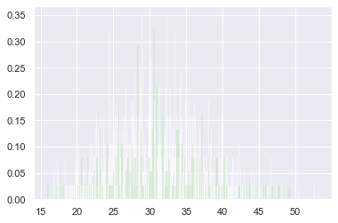

```python
num_of_bins = df['bmi'].count()
plt.hist(df['bmi'], num_of_bins, density=1, facecolor='green', alpha=0.5)
plt.show()
```

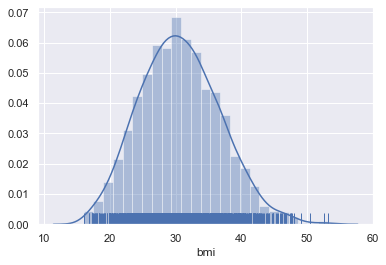

```python
sns.distplot(df['bmi'], kde = True, rug = True)
```

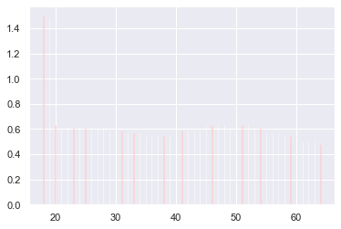

```python
num_of_bins = df['age'].count()
plt.hist(df['age'], num_of_bins, density=1, facecolor='red', alpha=0.5)
plt.show()
```

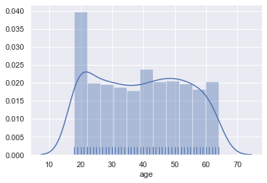

```python
sns.distplot(df['age'], kde = True, rug = True)
```

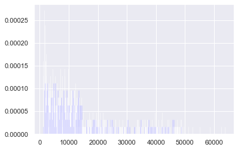

```python
num_of_bins = df['charges'].count()
plt.hist(df['charges'], num_of_bins, density=1, facecolor='blue', alpha=0.5)
plt.show()
```

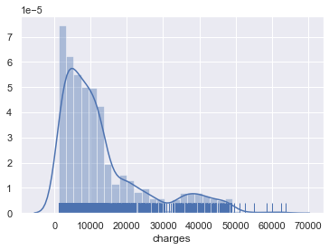

```python
sns.distplot(df['charges'], kde = True, rug = True)
```

```python
# Q3) (f) Measure of skewness of ‘bmi’, ‘age’ and ‘charges’ columns
```

```python
print('SKEWNESS FOR DATA:')
print('1. Skewness for BMI :     ', skew(df['bmi']))
print('2. Skewness for Age :     ', skew(df['age']))
print('3. Skewness for Charges : ', skew(df['charges']))
```

```
SKEWNESS FOR DATA:
1. Skewness for BMI :      0.28372857291709386
2. Skewness for Age :      0.055610083072599126
3. Skewness for Charges :  1.5141797118745743
```

```python
# Q3) (g) Checking the presence of outliers in ‘bmi’, ‘age’ and ‘charges columns

# I have plotted boxplots to check for outliers
# There are two boxplots plotted for each attribute
# 1. boxplot of just the given variable
# 2. boxplot of the given variable seprately for the corresponding number of children
```

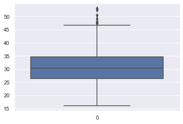

```python
sns.boxplot(data = df['bmi'])
# Outliers exist
```

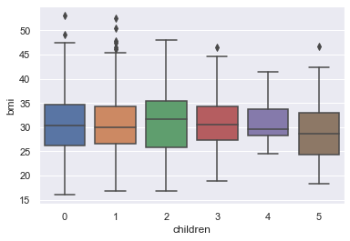

```python
sns.boxplot(x='children',y='bmi',data=df)
# Outliers exist when the children are either none, 1, 3, and 5
```

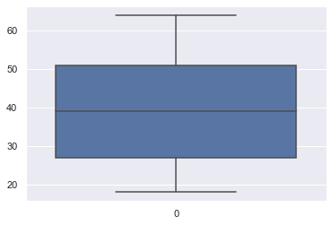

```python
sns.boxplot(data = df['age'])
```

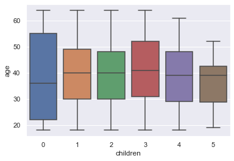

```python
sns.boxplot(x='children',y='age',data=df)
```

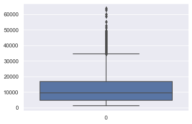

```python
sns.boxplot(data = df['charges'])
```

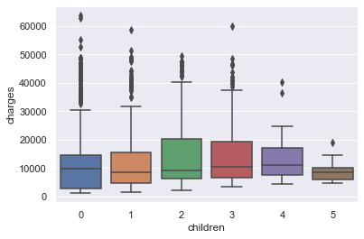

```python
sns.boxplot(x='children',y='charges',data=df)
# # Outliers exist in all cases
```

```python
# Q3) (h) Distribution of categorical columns (include children)
```

```python
df.describe(include='all')
```

|  | age | sex | bmi | children | smoker | region | charges |
| --- | --- | --- | --- | --- | --- | --- | --- |
| count | 1338.000000 | 1338 | 1338.000000 | 1338.000000 | 1338 | 1338 | 1338.000000 |
| unique | NaN | 2 | NaN | NaN | 2 | 4 | NaN |
| top | NaN | male | NaN | NaN | no | southeast | NaN |
| freq | NaN | 676 | NaN | NaN | 1064 | 364 | NaN |
| mean | 39.207025 | NaN | 30.663397 | 1.094918 | NaN | NaN | 13270.422265 |
| std | 14.049960 | NaN | 6.098187 | 1.205493 | NaN | NaN | 12110.011237 |
| min | 18.000000 | NaN | 15.960000 | 0.000000 | NaN | NaN | 1121.873900 |
| 25% | 27.000000 | NaN | 26.296250 | 0.000000 | NaN | NaN | 4740.287150 |
| 50% | 39.000000 | NaN | 30.400000 | 1.000000 | NaN | NaN | 9382.033000 |
| 75% | 51.000000 | NaN | 34.693750 | 2.000000 | NaN | NaN | 16639.912515 |
| max | 64.000000 | NaN | 53.130000 | 5.000000 | NaN | NaN | 63770.428010 |

```python
df. info()
```

```
<class 'pandas.core.frame.DataFrame'>
RangeIndex: 1338 entries, 0 to 1337
Data columns (total 7 columns):
 #   Column    Non-Null Count  Dtype
---  ------    --------------  -----
 0   age       1338 non-null   int64
 1   sex       1338 non-null   object
 2   bmi       1338 non-null   float64
 3   children  1338 non-null   int64
 4   smoker    1338 non-null   object
 5   region    1338 non-null   object
 6   charges   1338 non-null   float64
dtypes: float64(2), int64(2), object(3)
memory usage: 57.6+ KB
```

```python
inc_cat = df[['sex', 'children', 'smoker', 'region']]
inc_cat
```

|  | sex | children | smoker | region |
| --- | --- | --- | --- | --- |
| 0 | female | 0 | yes | southwest |
| 1 | male | 1 | no | southeast |
| 2 | male | 3 | no | southeast |
| 3 | male | 0 | no | northwest |
| 4 | male | 0 | no | northwest |
| ... | ... | ... | ... | ... |
| 1333 | male | 3 | no | northwest |
| 1334 | female | 0 | no | northeast |
| 1335 | female | 0 | no | southeast |
| 1336 | female | 0 | no | southwest |
| 1337 | female | 0 | yes | northwest |

1338 rows × 4 columns

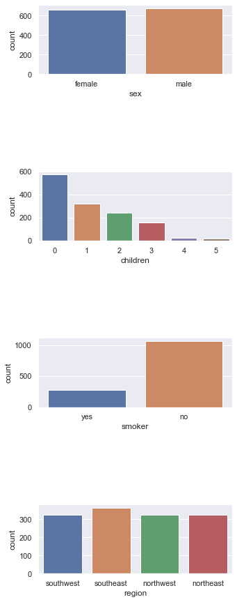

```python
diagram = plt.figure(figsize=(5,15))

axis1 = diagram.add_subplot(7,1,1)
sns.countplot(data = inc_cat, x = 'sex', ax=axis1)

axis2 = diagram.add_subplot(7,1,3)
sns.countplot(data = inc_cat, x = 'children', ax=axis2)

axis3 = diagram.add_subplot(7,1,5)
sns.countplot(data = inc_cat, x = 'smoker', ax=axis3)

axis4 = diagram.add_subplot(7,1,7)
sns.countplot(data = inc_cat, x = 'region', ax=axis4)
```

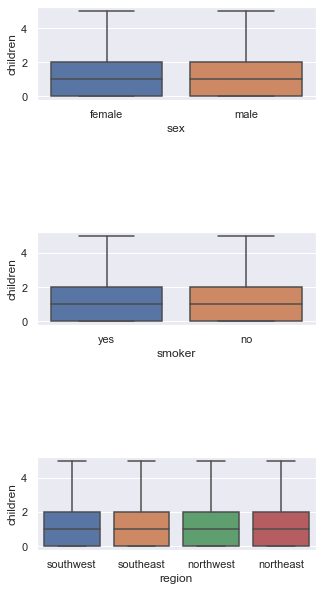

```python
diagram = plt.figure(figsize=(5,10))

axis1 = diagram.add_subplot(5,1,1)
sns.boxplot(data = inc_cat, x = 'sex', y='children', ax=axis1)

axis3 = diagram.add_subplot(5,1,3)
sns.boxplot(data = inc_cat, x = 'smoker', y='children', ax=axis3)

axis4 = diagram.add_subplot(5,1,5)
sns.boxplot(data = inc_cat, x = 'region', y='children', ax=axis4)
```

```python
# Q3) (i) Pair plot that includes all the columns of the data frame
```

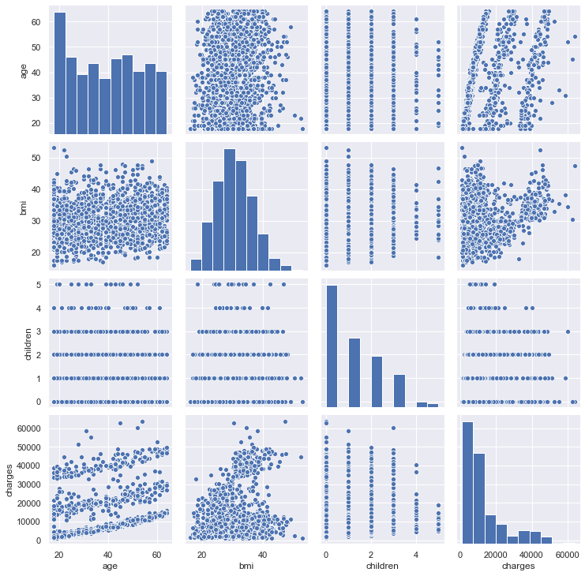

```python
sns.pairplot(df)
```

```python
# Q4) (a) Do charges of people who smoke differ significantly from the people who don't?
```

```python
df[df.smoker == 'yes'][['charges']].mean()
```

```
charges    32050.231832
dtype: float64
```

```python
df[df.smoker == 'no'][['charges']].mean()
```

```
charges    8434.268298
dtype: float64
```

```python
df[df.smoker == 'yes'][['charges']].median()
```

```
charges    34456.34845
dtype: float64
```

```python
df[df.smoker == 'no'][['charges']].median()
```

```
charges    7345.4053
dtype: float64
```

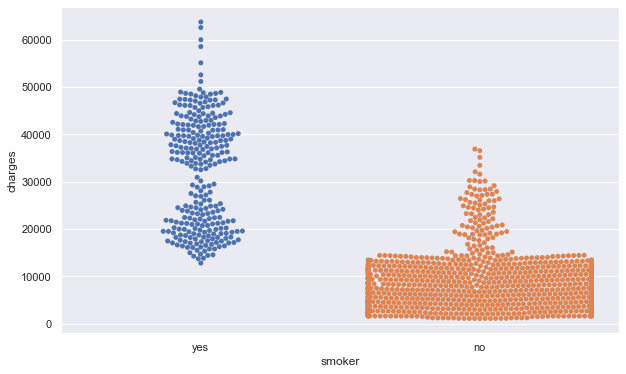

```python
plt.figure(figsize=(10,6))
sns.swarmplot(x='smoker',y='charges',data=df[['smoker', 'charges']])
plt.show()
```

```python
# Answer to Q4) (a) :
# YES
# Charges of people who smoke differ significantly from the people who don't.
# In case of non smokers charges are lower than smokers
```

```python
# Q4) (b) Does bmi of males differ significantly from that of females?
```

```python
df[df.sex == 'male'][['bmi']].mean()
```

```
bmi    30.943129
dtype: float64
```

```python
df[df.sex == 'female'][['bmi']].mean()
```

```
bmi    30.377749
dtype: float64
```

```python
df[df.sex == 'male'][['bmi']].median()
```

```
bmi    30.6875
dtype: float64
```

```python
df[df.sex == 'female'][['bmi']].median()
```

```
bmi    30.1075
dtype: float64
```

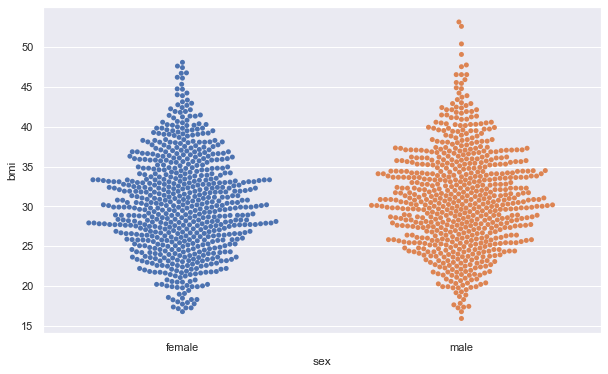

```python
plt.figure(figsize=(10,6))
sns.swarmplot(x='sex',y='bmi',data=df[['sex', 'bmi']])
plt.show()
```

```python
# Answer to Q4) (b) :
# NO
# bmi of males DOESN'T differ significantly from that of females
# as shown by the swarm plots reflecting the mean and median values
```

```python
# Q4) (c) Is the proportion of smokers significantly different in different genders?
```

```python
proportion = df[df.smoker == 'yes']
proportion1 = proportion[['smoker','sex']]
prop_female = proportion1[proportion1.sex == 'female']
prop_male = proportion1[proportion1.sex == 'male']
prop_male = prop_male["sex"].count()/df[df.smoker == 'yes']["smoker"].count()
prop_female = prop_female["sex"].count()/df[df.smoker == 'yes']["smoker"].count()
prop_male, prop_female
```

```
(0.5802919708029197, 0.4197080291970803)
```

```python
# Answer to Q4) (c)
# NO
# The proportion of smokers IS NOT significantly different in different genders.
# Difference between genders = 0.160583942 (less than 0.20)
# I have taken the assumption that: To be significantly different the difference in proportion
# would need to be greater than 0.20
```

```python
# Q4) (d) Is the distribution of bmi across women with no children, one child and two children, the same?
```

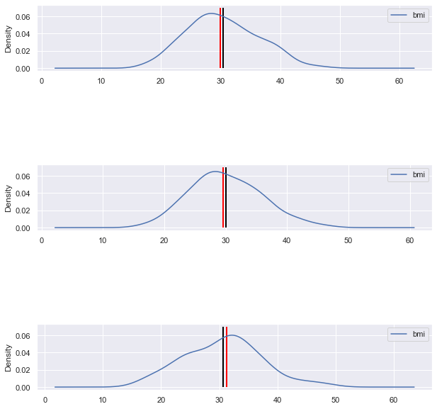

```python
female = df[df.sex == 'female']
diagram = plt.figure(figsize=(10,6))

ax1 = diagram.add_subplot(5,1,1)
children_0 = female[female.children == 0]
children_0[['bmi']].plot(kind="density", figsize=(10,10), ax=ax1)
plt.vlines(children_0[['bmi']].mean(), ymin=0, ymax=0.07, linewidth=2.0, color='black')
plt.vlines(children_0[['bmi']].median(), ymin=0, ymax=0.07, linewidth=2.0, color='red')

ax2 = diagram.add_subplot(5,1,3)
children_1 = female[female.children == 1]
children_1[['bmi']].plot(kind="density", figsize=(10,10), ax=ax2)
plt.vlines(children_1[['bmi']].mean(), ymin=0, ymax=0.07, linewidth=2.0, color='black')
plt.vlines(children_1[['bmi']].median(), ymin=0, ymax=0.07, linewidth=2.0, color='red')

ax3 = diagram.add_subplot(5,1,5)
children_2 = female[female.children == 2]
children_2[['bmi']].plot(kind="density", figsize=(10,10), ax=ax3)
plt.vlines(children_2[['bmi']].mean(), ymin=0, ymax=0.07, linewidth=2.0, color='black')
plt.vlines(children_2[['bmi']].median(), ymin=0, ymax=0.07, linewidth=2.0, color='red')
```

```python
# Answer to Q4) (d)
# The distribution of bmi across women with no children, one child and two children are VERY SIMILAR.
# When there are no children and 1 child, graphs are almost identical and very slightly right skewed.
# Mean and Medians are also ver similar for all 3 graphs.
# When children are 2, the shape of the graph is slightly different (slightly left skewed) as compared to the others.
```

```python
# -------- END OF PROJECT --------
```